# so_compensation_deep_dive

## 1. Introduction & Goal

**Project Title:**  
Compensation Deep Dive: Stack Overflow Developer Survey 2024

**Context & Motivation:**  
The Stack Overflow Annual Developer Survey collects detailed information about developers’ backgrounds, skills, and compensation from around the world. Understanding compensation trends helps professionals benchmark their own earnings, informs recruiters about market rates, and highlights geographic or demographic disparities in pay. In this analysis, we will focus on `ConvertedCompYearly`—the yearly compensation (in USD) reported by respondents—and explore how it varies by country, age, education level, and developer role.

**Objectives:**

1. Clean and prepare the salary column (`ConvertedCompYearly`) for analysis, including handling missing or invalid values.
2. Compute and visualize median compensation across the top 10 respondent countries.
3. Investigate salary distributions by age group and education level.
4. Analyze compensation for the most common developer roles.
5. Create clear, interpretable visualizations (boxplots, bar charts, heatmaps) and summarize actionable insights.

**Notebook Structure:**

1. **Data Loading & Column Verification**: Read the survey data and confirm key columns.
2. **Data Cleaning & Transformation**: Filter and transform `ConvertedCompYearly`, bin ages and education, and explode `DevType`.
3. **Analysis & Visualization**: Compute median salaries by country, age group, education, and role; generate boxplots, bar charts, and heatmaps.
4. **Conclusions & Insights**: Summarize key findings and discuss potential implications.

## 2. Data Loading & Column Verification

We’ll load the 2024 Stack Overflow survey responses (`survey_results_public.csv`) and verify that all relevant columns for compensation analysis are present. Specifically, we want to ensure that:

- `ConvertedCompYearly` (annual salary in USD)
- `Country` (respondent’s country)
- `Age` (age bracket, e.g., “25-34”)
- `EdLevel` (highest education level)
- `DevType` (developer role(s), semicolon‐separated)
- `YearsCodePro` (years coding professionally, e.g., “3-5 years”)

Once confirmed, we can proceed directly to cleaning and transformation.

#### 2.1. Code Cells

#### Cell 1: Import Libraries & Load the CSV

```python
import pandas as pd
import numpy as np
import matplotlib.pyplot as plt
import seaborn as sns

# Load the primary survey data
df = pd.read_csv('/Users/honeymustard/Desktop/Stack Overflow Project/Data/Raw/stack-overflow-developer-survey-2024/survey_results_public.csv', low_memory=False)

# Show the total shape of the DataFrame (rows, columns)
print("Survey data shape:", df.shape)
```

```
Survey data shape: (65437, 114)
```

#### Cell 2: Verify Presence of Key Columns

```python
# List all column names and check for the keys
print("All columns:", df.columns.tolist())

# Verify that our key columns exist
required_columns = ['ConvertedCompYearly', 'Country', 'Age', 'EdLevel', 'DevType', 'YearsCodePro']
missing = [col for col in required_columns if col not in df.columns]
if missing:
    print("Missing columns:", missing)
else:
    print("All required columns are present!")
```

```
All columns: ['ResponseId', 'MainBranch', 'Age', 'Employment', 'RemoteWork', 'Check', 'CodingActivities', 'EdLevel', 'LearnCode', 'LearnCodeOnline', 'TechDoc', 'YearsCode', 'YearsCodePro', 'DevType', 'OrgSize', 'PurchaseInfluence', 'BuyNewTool', 'BuildvsBuy', 'TechEndorse', 'Country', 'Currency', 'C…
All required columns are present!
```

#### Cell 3: Preview Key Columns & Sample Rows

```python
# Display the first few rows of only the key columns
df[required_columns].head(10)
```

|  | ConvertedCompYearly | Country | Age | EdLevel | DevType | YearsCodePro |
| --- | --- | --- | --- | --- | --- | --- |
| 0 | NaN | United States of America | Under 18 years old | Primary/elementary school | NaN | NaN |
| 1 | NaN | United Kingdom of Great Britain and Northern I... | 35-44 years old | Bachelor’s degree (B.A., B.S., B.Eng., etc.) | Developer, full-stack | 17 |
| 2 | NaN | United Kingdom of Great Britain and Northern I... | 45-54 years old | Master’s degree (M.A., M.S., M.Eng., MBA, etc.) | Developer Experience | 27 |
| 3 | NaN | Canada | 18-24 years old | Some college/university study without earning ... | Developer, full-stack | NaN |
| 4 | NaN | Norway | 18-24 years old | Secondary school (e.g. American high school, G... | Developer, full-stack | NaN |
| 5 | NaN | United States of America | Under 18 years old | Primary/elementary school | Student | NaN |
| 6 | NaN | United States of America | 35-44 years old | Professional degree (JD, MD, Ph.D, Ed.D, etc.) | Academic researcher | 7 |
| 7 | NaN | Uzbekistan | 18-24 years old | Secondary school (e.g. American high school, G... | Student | NaN |
| 8 | NaN | United Kingdom of Great Britain and Northern I... | 45-54 years old | Professional degree (JD, MD, Ph.D, Ed.D, etc.) | Academic researcher | NaN |
| 9 | NaN | Serbia | 35-44 years old | Master’s degree (M.A., M.S., M.Eng., MBA, etc.) | Developer, full-stack | 11 |

## 3. Data Cleaning & Transformation

Raw survey data often contains missing, invalid, or inconsistent values. In this section, we will:

1. **Filter Salary**
   - Remove rows where `ConvertedCompYearly` is null, zero, or negative.
2. **Transform Salary**
   - Create a **log‐transformed** salary column (`SalaryLog`) to reduce skew.
   - (Optionally) Create a **Min–Max normalized** salary column (`SalaryMinMax`).
3. **Bin Age**
   - Convert `Age` strings (e.g., “25-34”) into ordered `AgeGroup` categories.
4. **Bucket Education**
   - Simplify `EdLevel` text into broad buckets like “NoDegree,” “Associate,” “Bachelors,” “Masters,” “PostGrad.”
5. **Explode Developer Roles**
   - Split `DevType` (semicolon‐separated) and `.explode()` so each row represents one respondent‐role.

Below are the code cells for each step.

#### Cell 3.1: Filter & Clean Salary

```python
# 3.1. Filter rows for valid, positive salary
df_clean = df.dropna(subset=['ConvertedCompYearly']).copy()
df_clean = df_clean[df_clean['ConvertedCompYearly'] > 0]

print("Rows with valid salaries:", df_clean.shape)
```

```
Rows with valid salaries: (23435, 114)
```

#### Cell 3.2: Salary Transformations

```python
# 3.2.1: Log-transform salary
df_clean['SalaryLog'] = np.log1p(df_clean['ConvertedCompYearly'])

# 3.2.2: Min-Max normalize salary
min_sal = df_clean['ConvertedCompYearly'].min()
max_sal = df_clean['ConvertedCompYearly'].max()
df_clean['SalaryMinMax'] = (df_clean['ConvertedCompYearly'] - min_sal) / (max_sal - min_sal)

df_clean[['ConvertedCompYearly','SalaryLog','SalaryMinMax']].describe().round(2)
```

|  | ConvertedCompYearly | SalaryLog | SalaryMinMax |
| --- | --- | --- | --- |
| count | 23435.00 | 23435.00 | 23435.00 |
| mean | 86155.29 | 10.79 | 0.01 |
| std | 186756.97 | 1.40 | 0.01 |
| min | 1.00 | 0.69 | 0.00 |
| 25% | 32712.00 | 10.40 | 0.00 |
| 50% | 65000.00 | 11.08 | 0.00 |
| 75% | 107971.50 | 11.59 | 0.01 |
| max | 16256603.00 | 16.60 | 1.00 |

#### Cell 3.3: Bin Age into Ordered Categories

```python
# 3.2.4: View unique Age buckets
df_clean['Age'].value_counts()
```

```
Age
25-34 years old       10369
35-44 years old        6231
18-24 years old        3433
45-54 years old        2329
55-64 years old         863
65 years or older       137
Under 18 years old       64
Prefer not to say         9
Name: count, dtype: int64
```

```python
# Define an ordered category for Age
age_order = ['Under 18 years old','18-24 years old','25-34 years old','35-44 years old','45-54 years old','55-64 years old','65 years or older','Prefer not to say']
df_clean['AgeGroup'] = pd.Categorical(df_clean['Age'], categories=age_order, ordered=True)

# Confirm new column
df_clean['AgeGroup'].value_counts().sort_index()
```

```
AgeGroup
Under 18 years old       64
18-24 years old        3433
25-34 years old       10369
35-44 years old        6231
45-54 years old        2329
55-64 years old         863
65 years or older       137
Prefer not to say         9
Name: count, dtype: int64
```

#### Cell 3.4: Bucket Education Levels

```python
# 3.4. Bucket EdLevel into broad categories
def simplify_education(level):
    if pd.isna(level):
        return 'NoAnswer'
    lvl = level.lower()
    if 'bachelor' in lvl:
        return 'Bachelors'
    if 'master' in lvl:
        return 'Masters'
    if 'professional' in lvl or 'doctoral' in lvl or 'phd' in lvl:
        return 'PostGrad'
    if 'associate' in lvl:
        return 'Associate'
    if 'no formal education' in lvl:
        return 'NoDegree'
    return 'Other'

df_clean['EdBucket'] = df_clean['EdLevel'].apply(simplify_education)
df_clean['EdBucket'].value_counts()
```

```
EdBucket
Bachelors    10365
Masters       6831
Other         4334
PostGrad      1155
Associate      750
Name: count, dtype: int64
```

#### Cell 3.5: Explode Developer Roles

```python
# 3.5. Explode DevType (semicolon-separated roles)
roles_df = df_clean[['ConvertedCompYearly', 'DevType']].dropna(subset=['DevType']).copy()
roles_df['Role'] = roles_df['DevType'].str.split(';')
roles_exploded = roles_df.explode('Role').copy()
roles_exploded['Role'] = roles_exploded['Role'].str.strip()

roles_exploded['Role'].value_counts().head(10)
```

```
Role
Developer, full-stack                            8290
Developer, back-end                              4738
Developer, front-end                             1412
Developer, desktop or enterprise applications    1061
Developer, mobile                                 825
Developer, embedded applications or devices       745
Other (please specify):                           651
Data engineer                                     579
Engineering manager                               541
DevOps specialist                                 489
Name: count, dtype: int64
```

## 4. Analysis & Visualization

In this section, we’ll compute and plot:

1. **Median Salary by Country** (top 10 countries)
2. **Salary Distribution by Age Group** (boxplot of `SalaryLog`)
3. **Median Salary by Education Level** (`EdBucket`)
4. **Median Salary by Developer Role** (top 10 roles from `roles_exploded`)
5. *(Optional)* **Heatmap** of median `SalaryLog` by `Country` and `AgeGroup`

#### Cell 4.1: Median Salary by Country

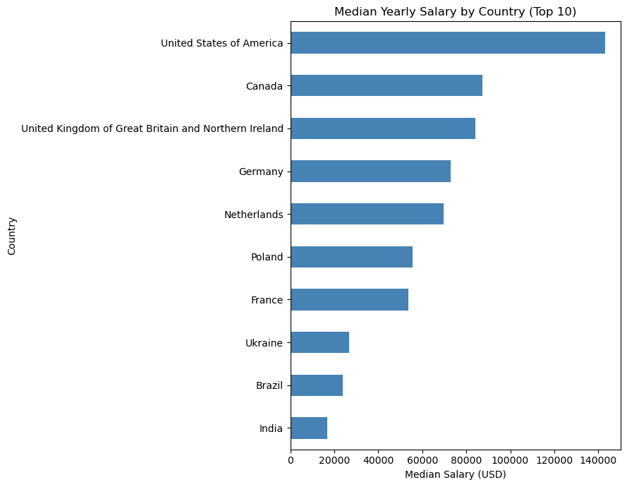

```python
# 4.1. Median Salary by Top 10 Countries
top_countries = df_clean['Country'].value_counts().head(10).index
med_salary_country = (
    df_clean[df_clean['Country'].isin(top_countries)]
    .groupby('Country')['ConvertedCompYearly']
    .median()
    .sort_values(ascending=False)
)

plt.figure(figsize=(9,7))
med_salary_country.plot.barh(color='steelblue')
plt.title('Median Yearly Salary by Country (Top 10)')
plt.xlabel('Median Salary (USD)')
plt.gca().invert_yaxis()
plt.tight_layout()
plt.show()
```

#### Cell 4.2: Salary Distribution by Age Group

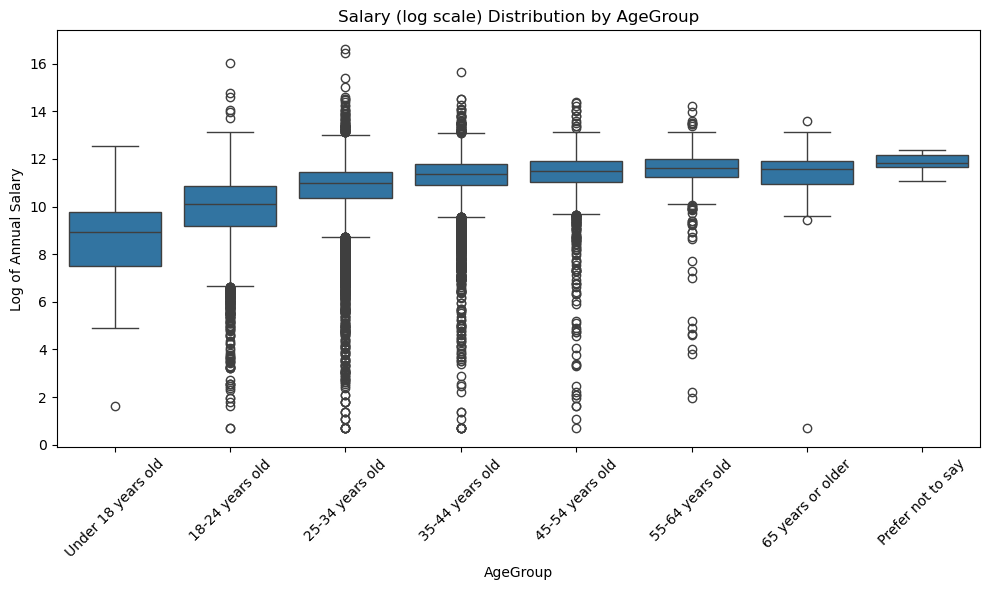

```python
plt.figure(figsize=(10,6))
sns.boxplot(x='AgeGroup', y='SalaryLog', data=df_clean)
plt.title('Salary (log scale) Distribution by AgeGroup')
plt.xlabel('AgeGroup')
plt.ylabel('Log of Annual Salary')
plt.xticks(rotation=45)
plt.tight_layout()
plt.show()
```

#### Cell 4.3: Median Salary by Education Level

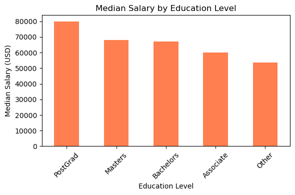

```python
med_salary_edu = (
    df_clean.groupby('EdBucket')['ConvertedCompYearly']
    .median()
    .sort_values(ascending=False)
)

plt.figure(figsize=(6,4))
med_salary_edu.plot.bar(color='coral')
plt.title('Median Salary by Education Level')
plt.xlabel('Education Level')
plt.ylabel('Median Salary (USD)')
plt.xticks(rotation=45)
plt.tight_layout()
plt.show()
```

#### Cell 4.4: Median Salary by Top 10 Developer Roles

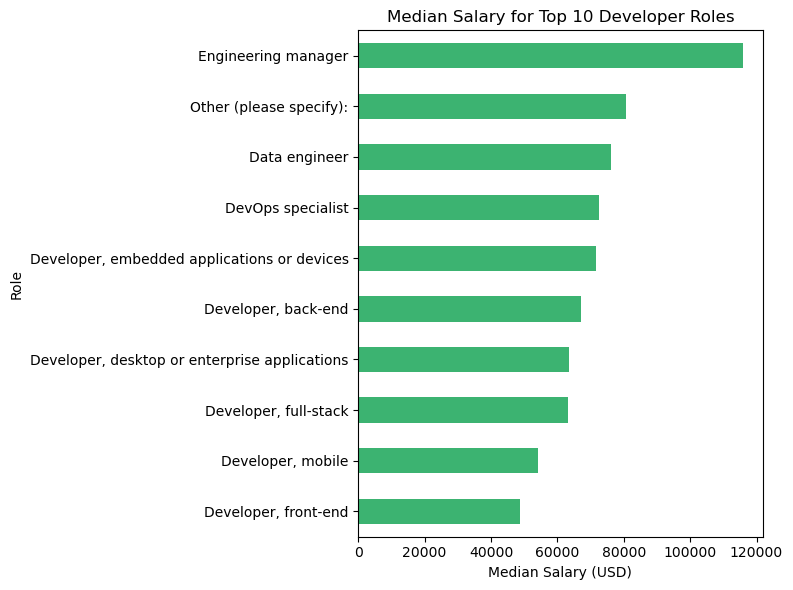

```python
top_roles = roles_exploded['Role'].value_counts().head(10).index
role_medians = (
    roles_exploded[roles_exploded['Role'].isin(top_roles)]
    .groupby('Role')['ConvertedCompYearly']
    .median()
    .sort_values(ascending=False)
)

plt.figure(figsize=(8,6))
role_medians.plot.barh(color='mediumseagreen')
plt.title('Median Salary for Top 10 Developer Roles')
plt.xlabel('Median Salary (USD)')
plt.gca().invert_yaxis()
plt.tight_layout()
plt.show()
```

#### Cell 4.5: (Optional) Heatmap of SalaryLog by Country & AgeGroup

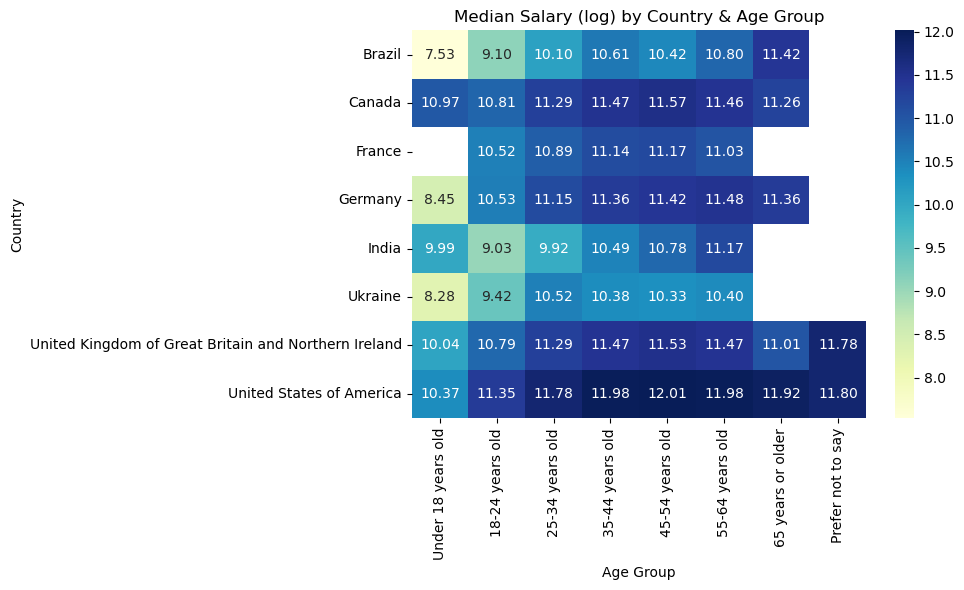

```python
# 4.5. Prepare pivot table
countries_for_heatmap = top_countries[:8]  # Top 8 to keep it legible
pivot_table = (
    df_clean[df_clean['Country'].isin(countries_for_heatmap)]
    .pivot_table(
        values='SalaryLog',
        index='Country',
        columns='AgeGroup',
        aggfunc='median',
        observed=False  # silences the FutureWarning

    )
)

plt.figure(figsize=(10,6))
sns.heatmap(pivot_table, annot=True, fmt=".2f", cmap='YlGnBu')
plt.title('Median Salary (log) by Country & Age Group')
plt.xlabel('Age Group')
plt.ylabel('Country')
plt.tight_layout()
plt.show()
```

## 5. Conclusions & Insights

### 5.2 Contextual Interpretation

**Regional Differences:**  
Higher salaries in the U.S. and Canada reflect both strong tech sector demand and higher costs of living. These regions also tend to attract or retain more senior developers.

**Educational Return:**  
While a formal degree isn’t a strict requirement for high pay in tech, advanced degrees still correlate with higher compensation, especially in managerial or specialized roles.

**Role Definitions:**  
Engineering Managers likely reflect leadership positions with broader responsibilities, while “Other” may include specialized or executive roles not captured by predefined survey categories.

### 5.3 Business & Career Implications

**For Hiring Managers:**  
Benchmark salaries in the U.S. and Canada at a premium and be prepared to offer competitive packages for experienced professionals or individuals with postgraduate degrees.

**For Educators/Bootcamps:**  
Encourage pathways toward postgraduate or leadership education for those targeting higher-earning roles. The data shows a meaningful correlation between formal education and compensation.

### 5.4 Potential Next Steps & Extensions

1. **Predictive Modeling:**  
   Build a regression model using features like `YearsCodePro`, `Country`, `EdLevel`, and `DevType` to predict salary outcomes.
2. **Trend Analysis Over Time:**  
   Compare with 2023 survey data to evaluate shifts in compensation trends year-over-year.
3. **Diversity Analysis:**  
   Expand analysis to explore salary trends by `Gender`, `Ethnicity`, or `RemoteWork` status, while acknowledging the limitations of self-reported data.
4. **Interactive Visualization:**  
   Build a Tableau or Plotly dashboard allowing users to filter salary trends by country, age, experience, and role interactively.

**In summary**, this compensation deep dive based on the 2024 Stack Overflow Annual Developer Survey highlights how geography, experience, education, and role type influence earnings in the tech industry. These insights are useful for job seekers, hiring teams, and educators who want to understand or respond to current compensation trends.